# Part II - (Loan Decision factors)

## by (Amr ELbana)

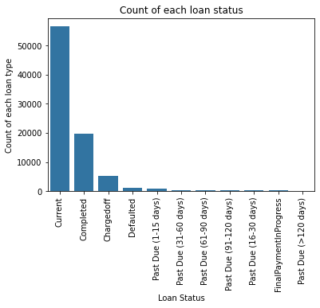

Most of the loan in the data set are currently running

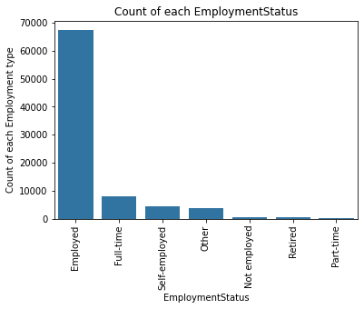

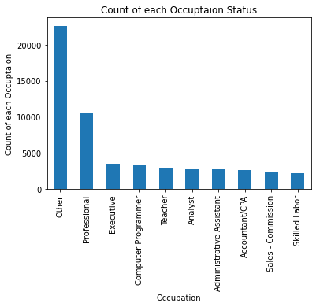

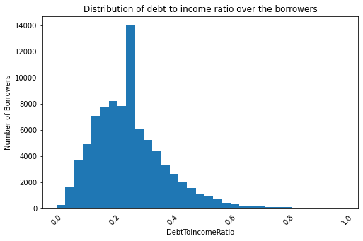

The previous plot is right skewed as most of the borrowers had 20% of their income as debt

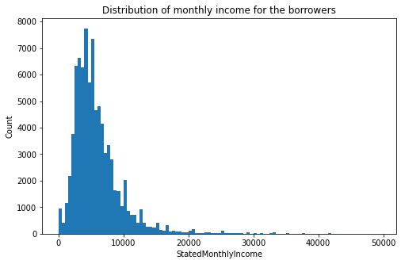

From the previous plot, it is obvious that most of the borrowers have less than 12000 monthly income

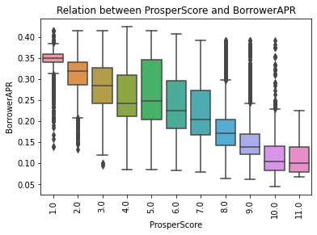

From the previous plot, it is obvious that Prosperscore ioncrease the BorroweAPR decreases as result to the trust of the borrowe

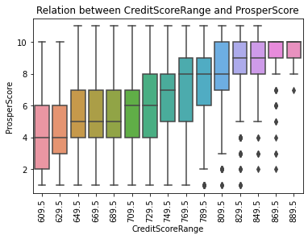

From the previous plot, it is obvious that CreditScore range increase the ProsperScore increasess as result to the trust of the borrowers As the credit score increase the trut in the client increases

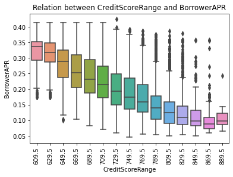

From the previous plot, it is obvious that CreditScore range increase the BorroweAPR decreases as result to the trust of the borrowers As the credit score increase the trust in the client increases and the APR score decreases

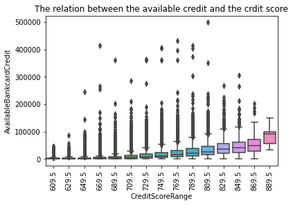

From the previous plot, it is obvious that As tha available bank credit increase the CreditScore range increase as result to the trust of the borrowers As the credit score increase the trust in the client increases and the APR score decreases

### Were there any interesting or surprising interactions between features?

1. High positive correlation between the loan amount and monthly payment
2. Moderate positive correlation between the availablebank credit card and creditscorerange
3. Moderate -ve correlation between the prosper score and the borooweAPR and rate
4. Moderate -ve correlation between the CreditScoreRange and the borooweAPR and rate
5. Moderate -ve correlation between the Loan original amount and the borrower APR and rate